# How Well Do Countries Eat? Part 2: Diversity of Foods in the Food Supply

[figure not shown]

Welcome. This is the second part of the analysis that looked at the food nutrient adequacy of countries in four income groups: High-income, upper-middle-income, lower-middle-income, and low-income. In this installment, I'm measuring food supply diversity by using Shannon diversity, a method that checks how much variation is there in the quantity of different foods in the food supply. According to this method, the more unequal the quantity of foods available in the food system, the less diverse the food system is.

The data for this indicator was the per capita food supply data for the year 2019, and it was obtained from [FAO's food balance sheets](https://www.fao.org/faostat/en/#data). The data was then grouped into 13 food groups, according to USDA's food composition tables. The units are expressed as kg per person per year. The data was of 2019 because this study was a study that looked at a period just before the COVID-19 pandemic.

# Executive Summary

1. The larger the economy, the more diverse the diet is.
2. High income countries leads all other groups, with a median diversity score of 81.4 out 100 (100 being most diverse), followed by upper-middle-income (78.3), lower-middle-income (72.3), and then low-income (68.8).
3. There is statistically significant difference between income groups; which means that it makes a difference in the diversity of your diet if you're born in a high-income country, upper-middle-income, lower-middle-income, or low income.

# Previewing the Dataset

```python
# Necessary packages
import pandas as pd
import numpy as np
import matplotlib.pyplot as plt
import seaborn as sns
from statsmodels.formula.api import ols
import statsmodels.api as sm
```

```python
data = pd.read_csv("/kaggle/input/food-supply-data-2019/1_Aggregated_Food_Supplies.csv")

data.head()
```

|  | Country | Income group | Region | Cereals | Roots & Tubers | Vegetables | Fruits & Plantains | Seeds, Nuts, and Oils | Starch and Sugars | Infant Food | Dairy and Egg Products | Finfish / Shellfish Products | Beef Products | Poultry | Legume and Legume Products | Spices & Herbs |
| --- | --- | --- | --- | --- | --- | --- | --- | --- | --- | --- | --- | --- | --- | --- | --- | --- |
| 0 | Spain | High income | Europe & Central Asia | 113.1 | 60.3 | 120.2 | 93.7 | 48.5 | 32.5 | 0.4 | 182.0 | 40.8 | 21.8 | 33.3 | 5.8 | 0.4 |
| 1 | Chile | High income | Latin America & Caribbean | 153.3 | 57.9 | 71.9 | 59.9 | 10.8 | 41.2 | 0.0 | 94.1 | 14.0 | 26.8 | 38.7 | 3.9 | 1.5 |
| 2 | Iceland | High income | Europe & Central Asia | 84.4 | 35.6 | 77.2 | 89.1 | 28.0 | 80.6 | 0.3 | 232.1 | 91.2 | 42.8 | 31.4 | 1.1 | 1.6 |
| 3 | Sweden | High income | Europe & Central Asia | 115.0 | 53.9 | 85.1 | 60.9 | 21.8 | 46.5 | 0.3 | 234.7 | 32.3 | 32.8 | 16.3 | 2.5 | 1.1 |
| 4 | Slovenia | High income | Europe & Central Asia | 140.1 | 38.1 | 99.5 | 104.7 | 16.6 | 44.7 | 0.0 | 192.0 | 13.2 | 20.9 | 29.1 | 1.4 | 0.3 |

# Programming the Shannon Formula

```python
# Creating a function for calculating Shannon_diversity

def Shannon_diversity(dataframe) :
    """Calculates Shannon Diversity from the DataFrame"""

    # Creating the "Total Column"
    dataframe.loc[:, "Total"] = dataframe.sum(axis=1)


    # Removing zeroes and NaNs (Dividing columns with these values to the total will bring something nobody wants.)
    some_list = list()

    for i, val in dataframe.iterrows():
        j = dataframe.loc[[i]].dropna(axis=1)

        j = j.loc[:, (j != 0).any(axis=0)]

        some_list.append(j)


    # The Shannon Diversity Index
    container_1 = list()

    for i in range(len(some_list)):
        frame = some_list[i]

        container_2 = list()

        for col in frame :
            if col != "Total":
                d_index = abs(frame[col] / frame["Total"] * np.log(frame[col] / frame["Total"]))

                container_2.append(d_index)
            else:
                continue

            index_array = np.array(container_2).sum()


        container_1.append(index_array)


    dataframe.loc[:, "Supply Diversity Indeces"] = container_1

    return pd.DataFrame(dataframe.loc[:, "Supply Diversity Indeces"])
```

# Calculating Shannon Diversity

```python
# Resetting the index
reset_indeces = data.set_index("Country")

reset_indeces.head()
```

| Country | Income group | Region | Cereals | Roots & Tubers | Vegetables | Fruits & Plantains | Seeds, Nuts, and Oils | Starch and Sugars | Infant Food | Dairy and Egg Products | Finfish / Shellfish Products | Beef Products | Poultry | Legume and Legume Products | Spices & Herbs |
| --- | --- | --- | --- | --- | --- | --- | --- | --- | --- | --- | --- | --- | --- | --- | --- |
| Spain | High income | Europe & Central Asia | 113.1 | 60.3 | 120.2 | 93.7 | 48.5 | 32.5 | 0.4 | 182.0 | 40.8 | 21.8 | 33.3 | 5.8 | 0.4 |
| Chile | High income | Latin America & Caribbean | 153.3 | 57.9 | 71.9 | 59.9 | 10.8 | 41.2 | 0.0 | 94.1 | 14.0 | 26.8 | 38.7 | 3.9 | 1.5 |
| Iceland | High income | Europe & Central Asia | 84.4 | 35.6 | 77.2 | 89.1 | 28.0 | 80.6 | 0.3 | 232.1 | 91.2 | 42.8 | 31.4 | 1.1 | 1.6 |
| Sweden | High income | Europe & Central Asia | 115.0 | 53.9 | 85.1 | 60.9 | 21.8 | 46.5 | 0.3 | 234.7 | 32.3 | 32.8 | 16.3 | 2.5 | 1.1 |
| Slovenia | High income | Europe & Central Asia | 140.1 | 38.1 | 99.5 | 104.7 | 16.6 | 44.7 | 0.0 | 192.0 | 13.2 | 20.9 | 29.1 | 1.4 | 0.3 |

```python
# Separating the table for calculations and the table for indexing
shannon_table = reset_indeces.iloc[:, 2:]

indexing_table = reset_indeces.iloc[:, :2]


# Calculating Shannon
food_supply_diversity_shannon = Shannon_diversity(shannon_table)

food_supply_diversity_shannon
```

| Country | Supply Diversity Indeces |
| --- | --- |
| Spain | 2.138885 |
| Chile | 2.105233 |
| Iceland | 2.115612 |
| Sweden | 2.019177 |
| Slovenia | 1.987958 |
| ... | ... |
| Mexico | 2.034659 |
| Ecuador | 1.950009 |
| Dominican Republic | 1.849328 |
| Cuba | 2.050092 |
| Lebanon | 2.085413 |

156 rows × 1 columns

```python
# Attaching the Shannon data with sizes of economy

food_supply_diversity_economized = pd.merge(indexing_table,
                                            food_supply_diversity_shannon,
                                            left_index=True,
                                            right_index=True).drop("Region", axis=1)

food_supply_diversity_economized
```

| Country | Income group | Supply Diversity Indeces |
| --- | --- | --- |
| Spain | High income | 2.138885 |
| Chile | High income | 2.105233 |
| Iceland | High income | 2.115612 |
| Sweden | High income | 2.019177 |
| Slovenia | High income | 1.987958 |
| ... | ... | ... |
| Mexico | Upper middle income | 2.034659 |
| Ecuador | Upper middle income | 1.950009 |
| Dominican Republic | Upper middle income | 1.849328 |
| Cuba | Upper middle income | 2.050092 |
| Lebanon | Upper middle income | 2.085413 |

156 rows × 2 columns

```python
# Scaling the result on a scale of 0-100 (0=Worst, 100=Best)

food_supply_diversity_economized["scaled_values"] = food_supply_diversity_economized["Supply Diversity Indeces"] * 100/np.log(13) # Thirteen is the number of food groups the index was calculated on. For further reading, consult the scaling done by Gustafson et al (2016): Seven Metrics of Sustainable Nutrition Security

food_supply_diversity_economized.head()
```

| Country | Income group | Supply Diversity Indeces | scaled_values |
| --- | --- | --- | --- |
| Spain | High income | 2.138885 | 83.388958 |
| Chile | High income | 2.105233 | 82.076972 |
| Iceland | High income | 2.115612 | 82.481614 |
| Sweden | High income | 2.019177 | 78.721908 |
| Slovenia | High income | 1.987958 | 77.504750 |

# Results

Charts below show a graphical representation of the obtained results.

```
[Text(0.5, 1.0, 'Distribution of Diversity Values for Different Economies'),
```

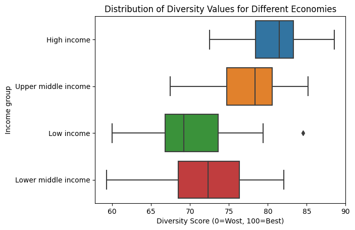

```python
sns.boxplot(x="scaled_values",
            y="Income group",
            data=food_supply_diversity_economized.sort_values("scaled_values", ascending=False),
            palette="tab10").set(title="Distribution of Diversity Values for Different Economies", xlabel="Diversity Score (0=Wost, 100=Best)")
```

```python
# Subsetting the outlier in low-incomes
outlier = food_supply_diversity_economized[(food_supply_diversity_economized["Income group"] == "Low income") &
                                           (food_supply_diversity_economized["scaled_values"] >= 80)]

outlier
```

| Country | Income group | Supply Diversity Indeces | scaled_values |
| --- | --- | --- | --- |
| Central African Republic | Low income | 2.168598 | 84.547388 |

```
[Text(0.5, 1.0, 'Diversity Values Re-Plotted'),
```

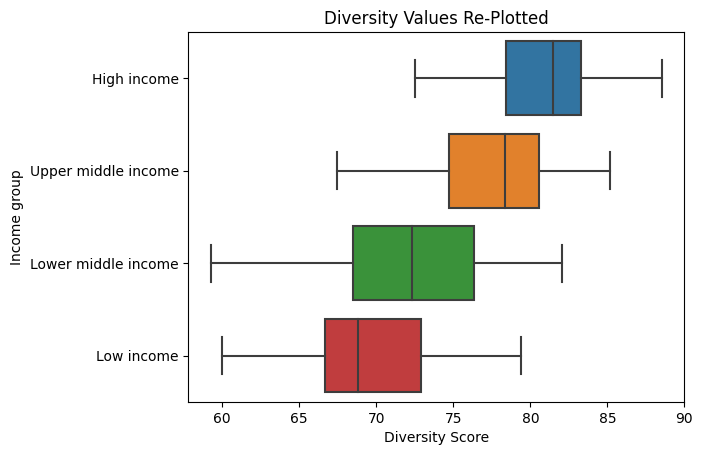

```python
# Removing the outlier
shannon_scores = food_supply_diversity_economized.drop("Central African Republic")


# Plotting the table again
sns.boxplot(data=shannon_scores.sort_values("scaled_values", ascending=False),
            x="scaled_values",
            y="Income group").set(title="Diversity Values Re-Plotted", xlabel="Diversity Score")
```

```python
# Running ANOVA on the data.

## Renaming columns
shannon_scores.columns = ["income_group", "diversity_score", "scaled_values"]


# Fitting and running the model
model = ols("diversity_score ~ C(income_group)", data=shannon_scores).fit()

anova_table = sm.stats.anova_lm(model, typ=2)

anova_table
```

|  | sum_sq | df | F | PR(>F) |
| --- | --- | --- | --- | --- |
| C(income_group) | 1.699462 | 3.0 | 41.830054 | 9.803046e-20 |
| Residual | 2.044932 | 151.0 | NaN | NaN |

```
[Text(0.5, 1.0, 'Median Diversity Score Per Income Group'),
```

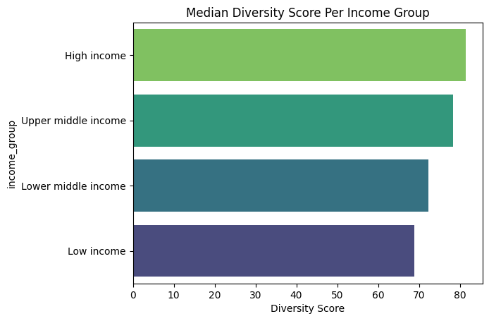

```python
# There's definitely a statistical significance. Ploting the median values.

## Grouping the original dataset by medians
df = shannon_scores.groupby("income_group")[["scaled_values"]].median().sort_values("scaled_values", ascending=False)

# Visualizing the medians
sns.barplot(data=df,
            x="scaled_values",
            y=df.index,
            palette="viridis_r").set(title="Median Diversity Score Per Income Group", xlabel="Diversity Score")
```

```python
df
```

| income_group | scaled_values |
| --- | --- |
| High income | 81.439363 |
| Upper middle income | 78.371719 |
| Lower middle income | 72.319410 |
| Low income | 68.814870 |

# Conclusion

1. High income countries leads all other group, with a median diversity score of 81.4 out 100 (100 being most diverse), followed by upper-middle-income (78.3), lower-middle-income (72.3), and then low-income (68.8).
2. There is statistically significant difference between income groups; which means it makes a difference in the diversity of your diet if you're born in a high-income country, upper-middle-income, lower-middle-income, or low income.
3. The larger the size of the economy, the more diverse the diet is.

For more of these kinds of works, visit **mukajangadavid.com**